# Milestone_Report_Capstone

Bhargav Dalal

November 25, 2016

## Synopsis

The project requires the development of a predictive model to predict the next word that is expected to be typed when a user enters a number of words as input. The corpus that could be used to train the model consists of a set of text files provided for download at [Swiftkey.zip](https://d396qusza40orc.cloudfront.net/dsscapstone/dataset/Coursera-SwiftKey.zip)

This report documents the initial analysis of the dataset and pre-processing steps taken to prepare for the development of a predictive model.

The R Code used is provided in Appendix 1.

### Reading the Data

While cycling through the loop to read the files, summary statistics about the file contents were additionally accumulated - such as the number of lines contained in the file, the total file size in number of characters, the maximum and avergae string lengths per line.

### Sampling the Data

In order to speed up processing during the initial phases of the project, it was decided to only use 5% of available data, i.e., 5% of the lines read were selected randomly to retain as sample text, the rest ignored. Later on, during model development, it is expected that a larger set of training data may be needed. The sample data statistics were added to the stats about the original documents.

Initially the data is examined and analysed at a very high level to determine what it consists of.

```
##    Number      Size MaxLen AveLen  Source
## 2  899288 206824505  40833    230   blogs
## 3 1010242 203223159  11384    201    news
## 4 2360148 162096031    140     69 twitter
## 5  213484  28610067   8949    134  sample
```

### Visualise Data Characteristics

The statistics about the data sets and sample data set are visualised in the following graphs. Due to twitter functionality, its longest string is capped at 140 characters.

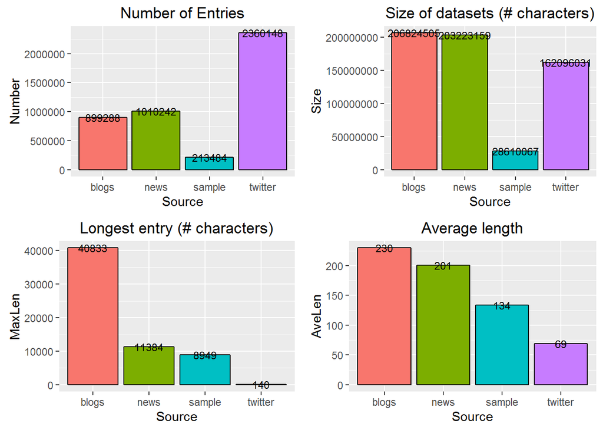

### Create Train and Test Sets from Sample Data

The sample data that was selected was then combined across the sources, with 70% randomly selected as a training set, the remaining 30% of lines to be kept for later testing of the predictive model. The two sets of text lines (training and test) were written out to text files so that further processing and analysis could pick up at this step without having to repeatedly read the large input text files.

```
##         Length Class            Mode
## content 149439 -none-           character
## meta         7 TextDocumentMeta list
```

### Pre-process and Clean the Training Data

In order to analyse the text contents further, the training set is cleaned by removing punctuation, foreign characters and numbers. It is converted to all lower case and extraneous white spaces were stripped out. It was decided not to do any word stemming, as this could skew results when the ulitmate objective is to predict the next word of a phrase entered by a user. For the same reason, it was also decided not to remove any stopwords (the frequently used words in the English language such as ‘the’, ‘and’, etc) it is expected that it is entirely likely that these stopwords will also most frequently have to be suggested as next words in a predictive model. I have also removed some of bad words by creating bad-words.txt.Click [here](http://www.cs.cmu.edu/~biglou/resources/bad-words.txt) to review it

```
## [1] "10057 lines contained unacceptable words per the external list which were replaced with PFLT"
```

### Analyse Training Data for Words and N-Grams

The pre-processed, cleaned and filtered training set was then analysed for the most frequently used words and n-grams consistring of 2 and 3 words, respectively (called bigrams and trigrams in the remainder of this report). Term-document matrices were developed for 2-grams and 3-grams, using the functionality available in the R tm library.

The analysis includes graphic representation of aspects of each of these such as number of unique terms/n-grams, most frequently used terms/n-grams.

As could be expected, the most frequent terms and n-grams mainly consist of stopwords.

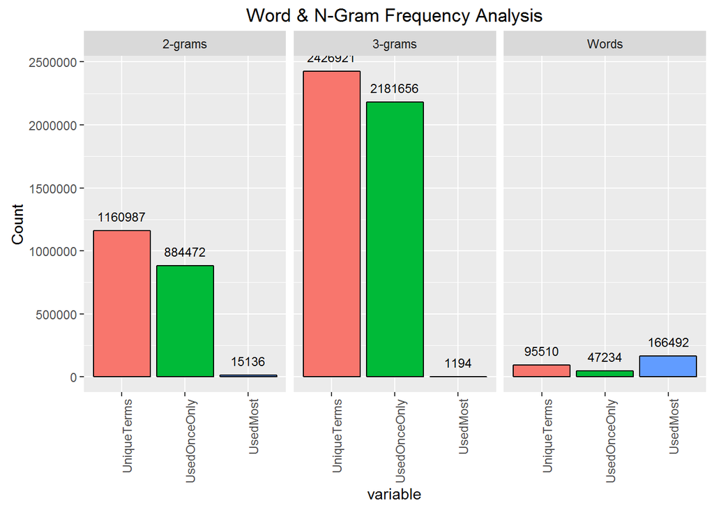

```
##     NTerm UniqueTerms UsedOnceOnly UsedMost
## 1   Words       95510        47234   166492
## 2 2-grams     1160987       884472    15136
## 3 3-grams     2426921      2181656     1194
```

From the data, it is seen that 95510 unique words were included in the sample. Considering that normal everyday English use require about 15000, it indicates that there are a large number of additional words. Visual inspection of the data shows that these consist of foreign words, names of people, places or things, misspelled word, and so forth. In the case of bigrams and trigrams, it is seen that a large proportion of the unique phrases occur only once in the data 884472 out of 1160987, and 2181656 out of 2426921, for 2-grams and 3-grams,respectively. It is expected that these infrequently used phrases will not play a large role in the predictive model to be developed due to the low probability of occurrence in the corpus. In the following graph, the number of occurrences of the 20 most frequently used words, 2-grams and 3-grams are visualised, again consisting almost exclusively of stopwords:

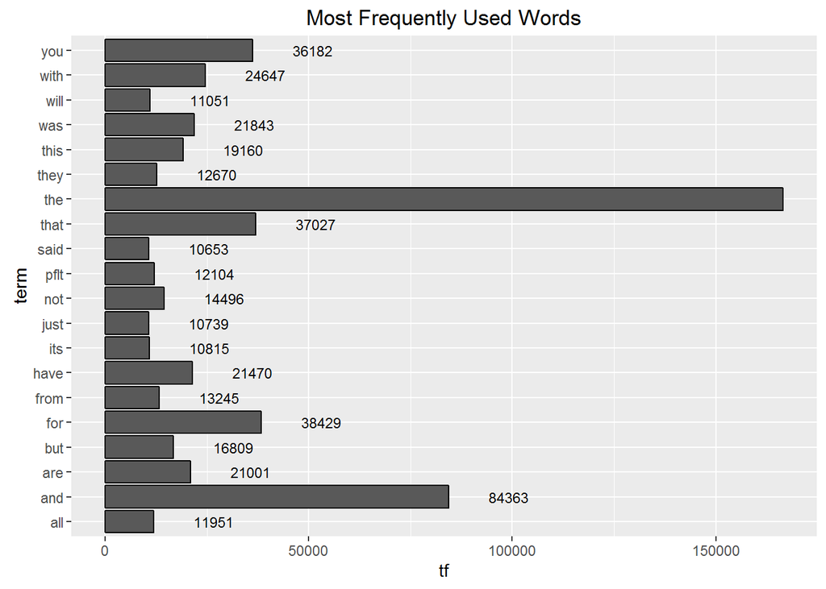

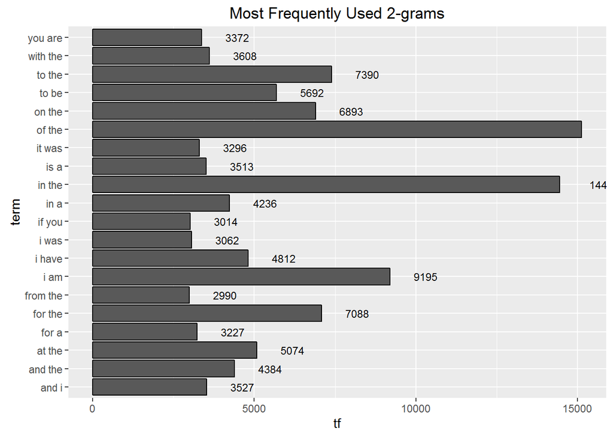

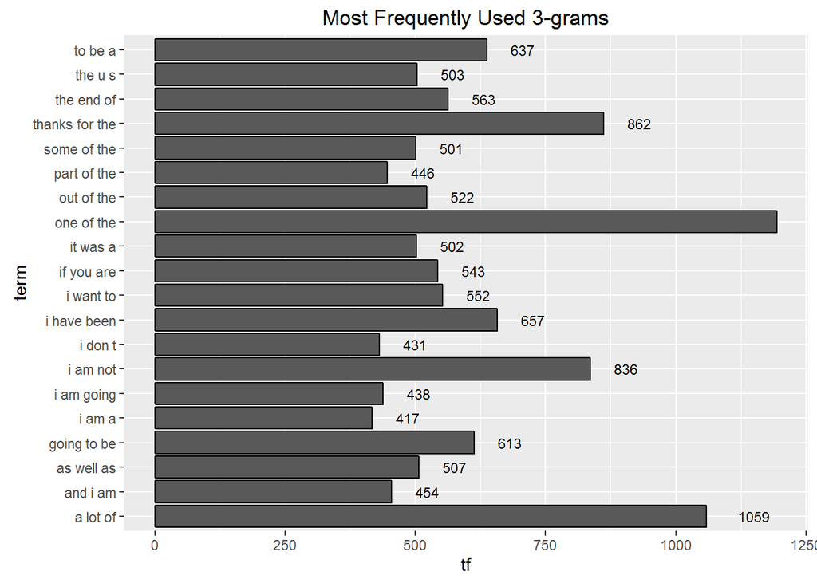

### Observations and Further Steps

1. The initial analysis of the data indicates that a small portion of the data (even as little as 5%) could render useful information about word and n-gram frequencies (probabilities) that would be valuable in the development of a model for predicting the next word based on user input given.
2. More research is needed about the role of punctuation, numbers and rare words or terms. While eliminated in the interim study, it is expected that these could be important in predictive models, and would probably need to be treated as special tokens.
3. Fix the problem with the “c” letter in the n-gram freq
4. Processsing and memory limitations on the Windows laptop on which the research is being conducted may force the researcher to settle for a less than ideal model as it takes a long time to process certain steps.

## Appendix 1 R code

```r
library(knitr)
library(RCurl)
library(RWeka)
library(tm)
library(ggplot2)
library(stringr)
library(gridExtra)
library(reshape2)
options(scipen = 999)
#
# Loading the file from the URL
#
#data_url <- "https://d396qusza40orc.cloudfront.net/dsscapstone/dataset/Coursera-SwiftKey.zip"
#zipfile <- "Swiftkey_data.zip"
#download.file(data_url, outfile, method = "auto")
#
# Check whether the load was successful and if so, unzip
#
#if(!file.exists(zipfile)) {
#    msg <- paste(zipfile, "does not exist", sep=" ")
#    stop(msg)
#}
#unzip(zipfile)
#
# After investigating what was unpacked from the ZIP file, obtain a vector with all the .txt file names
# in the en_US locale directory
#
engdir <- "D:/RdataRepo/WorkindDir/Capstone/final/en_US"
if(!file.exists(engdir)) {
    msg <- paste(engdir, "does not exist in working directory", sep=" ")
    stop(msg)
}
files <- list.files(engdir, pattern = "*.txt")
if (length(files)<1)
{
    msg <- paste(engdir, "does not contain .txt files", sep=" ")
    stop(msg)
}
#
# Cycle through the list of file names, reading each file as binary before converting to ASCII
#
fullstats <- data.frame(Number = 1L, Size = 1L, MaxLen = 1L, AveLen = 1L, stringsAsFactors=FALSE)
datanames <- c("Dummy")
thedata <- NULL
for (i in 1:length(files))
{
    dataname <- paste(engdir,files[i],sep="/")
    con <- file(dataname, "rb")
    textvector <- readLines(con,
#                         n = 20000,  # Comment out for final version
                            encoding="UTF-8")
    close(con)
    iconv(textvector, "UTF-8", "ascii", sub = " ")
    # Examine and record text characteristics such as file size, number of entries, longest and average string lengths.
    ndocs <- length(textvector)
    nchars <- sum(nchar(textvector))
    nlongest <- max(nchar(textvector))
    naverage <- round(nchars/ndocs,0)
    # Clean up the file name and add the stats for the data set to a data frame
    dataname <- gsub(".txt","",gsub("en_US.","",files[i]))
    datanames[length(datanames)+ 1] <- dataname
    fullstats <- rbind(fullstats,c(ndocs,nchars,nlongest,naverage))
    head(textvector)
    # Keep the text for later sampling
    thedata <- c(thedata, textvector)
}
#
# Set a seed so that the sampling is reprodicible and randomly select 5% of the data strings for inclusion
#
set.seed(12321)
doclen <- length(thedata)
samplendx <- sample(doclen, round(0.05*doclen))
thedata <- thedata[samplendx]
# Examine and record sample characteristics such as file size, number of entries, longest and average string lengths
ndocs <- length(thedata)
nchars <- sum(nchar(thedata))
nlongest <- max(nchar(thedata))
naverage <- round(nchars/ndocs,0)
datanames[length(datanames)+ 1] <- "sample"
fullstats <- rbind(fullstats,c(ndocs,nchars,nlongest,naverage))
fullstats$Source <- datanames
fullstats <- fullstats [-1,]
fullstats
g1 <- ggplot(data=fullstats, aes(x=Source, y=Number, fill=Source)) +
    geom_bar(colour="black", stat="identity") +
    geom_text(data = fullstats, aes(x=Source,y=Number,label=Number), position="identity", size = 3) +
    guides(fill=FALSE) + ggtitle("Number of Entries")
g2 <- ggplot(data=fullstats, aes(x=Source, y=Size, fill=Source)) +
    geom_bar(colour="black", stat="identity") +
    geom_text(data = fullstats, aes(x=Source,y=Size,label=Size), position="identity", size = 3) +
    guides(fill=FALSE) + ggtitle("Size of datasets (# characters)")
g3 <- ggplot(data=fullstats, aes(x=Source, y=MaxLen, fill=Source)) +
    geom_bar(colour="black", stat="identity") +
    geom_text(data = fullstats, aes(x=Source,y=MaxLen,label=MaxLen), position="identity", size = 3) +
    guides(fill=FALSE) + ggtitle("Longest entry (# characters)")
g4 <- ggplot(data=fullstats, aes(x=Source, y=AveLen, fill=Source)) +
    geom_bar(colour="black", stat="identity") +
    geom_text(data = fullstats, aes(x=Source,y=AveLen,label=AveLen), position="identity", size = 3) +
    guides(fill=FALSE) + ggtitle("Average length")
grid.arrange(g1,g2,g3,g4,ncol = 2)
#
#  The sample text is split 70-30 into a training and test set and written to file.
#
trainprob <- 0.7
doclen <- length(thedata)
samplendx <- sample(doclen, round(trainprob*doclen))
traindata <- thedata[samplendx]
testdata <- thedata[-samplendx]
rm(thedata)   # Done with this, clean memory
trainfile <- "traintext.txt"
writeLines(traindata,trainfile,useBytes = TRUE)
writeLines(testdata,"testtext.txt",useBytes = TRUE)
#
# Read the training data from the file
#
trainfile <- "traintext.txt"
if(!file.exists(trainfile)) {
    msg <- paste(trainfile, "does not exist", sep=" ")
    stop(msg)
}
traindata <- readLines(trainfile)
#
# Create a corpus with the training text so that the tm library could be used for analysis and processing
#
mycorpus <- Corpus(DirSource("./", pattern = trainfile),
                  readerControl = list(reader = readPlain,
                  language = "en_US",
                  load = TRUE))
summary(mycorpus[[1]])
#
# Function to strip out punctuation and foreign characters
#
removePunctuationAndForeign <- function(x)
{
    # Keep only letters, numbers and spaces, special treatment for certain apostrophes
    x <- gsub("n't", "nt", x)
    x <- gsub("'s", "s", x)
    x <- gsub("'re", " are", x)
    x <- gsub("'ve", " have", x)
    x <- gsub("i'm", "i am", x)
    x <- gsub("[^[:alnum:][:blank:]]", " ", x)
    x <- gsub("â", "", x)
    gsub("[šžþÃàáâãäåçèéêëìíîïðñòóôõöùúûüý¢]+", " ", x)
}
#
# Transform to lower case
#
mycorpus <- tm_map(mycorpus, content_transformer(tolower))
#
# Punctuation, foreign characters and numbers are removed
#
mycorpus <- tm_map(mycorpus, content_transformer(removePunctuationAndForeign))
mycorpus <- tm_map(mycorpus, removeNumbers)
#
# Strip extra white space
#
mycorpus <- tm_map(mycorpus, stripWhitespace)
mycorpus <- tm_map(mycorpus, PlainTextDocument)
#
#  Read the bad word list
#
replaceProfanity <- function(x,word)
{
    pattern <- paste("[ \r\n]",word,"[ \r\n]|^",word,"[ \r\n]|[ \r\n]", word, "$", sep ="")
    gsub(pattern, " PFLT ", x)
}
badfile <- "D:/RdataRepo/WorkindDir/Capstone/bad-words.txt"
if(!file.exists(badfile)) {
    msg <- paste(badfile, "does not exist", sep=" ")
    stop(msg)
}
badwords <- readLines(badfile)
for (i in 1:length(badwords))
{
    mycorpus <- tm_map(mycorpus, content_transformer(replaceProfanity),badwords[i])
}
prfntylst <- grep ("PFLT", mycorpus[[1]]$content)
msg <- paste (length(prfntylst),
              "lines contained unacceptable words per the external list which were replaced with PFLT",
              sep = " ")
print (msg)
cleanfile <- "cleantext.txt"
writeLines(mycorpus[[1]]$content, cleanfile, useBytes = TRUE)
#
# Determine frequency of words
# (for the moment a word is regarded as any string of charcaters surrounded by white space)
#
# length(mycorpus[[1]]$Content)
# sum(str_count(mycorpus[[1]]$content))
tdm <- TermDocumentMatrix(mycorpus)
unigrams <- data.frame(tdm$v, tdm$dimnames$Terms)
colnames(unigrams) <- c ("tf","term")
unigrams <- unigrams[order(unigrams$tf, decreasing=TRUE),]
usedonce <- nrow(unigrams[unigrams$tf < 2,]) # used only once
ngramstats <- c(1, length(unigrams$term), usedonce, unigrams$tf[1])
unigrams <- unigrams[unigrams$tf > 3,]
delim <- ' \r\n\t'
BigramTokenizer <- function(x)
{
    NGramTokenizer(x, Weka_control(min=2, max=2, delimiters=delim))
}
makeTDM2 <- function(x) {
    tdm <- TermDocumentMatrix(x, control=list(tokenize=BigramTokenizer))
    return(tdm)
}
TrigramTokenizer <- function(x)
{
    NGramTokenizer(x, Weka_control(min=3, max=3, delimiters=delim))
}

makeTDM3 <- function(x) {
    tdm <- TermDocumentMatrix(x, control=list(tokenize=TrigramTokenizer))
    return(tdm)
}
#
# Determine frequency of bigrams (sequences of 2 "words")
#
tdm2 <- makeTDM2(mycorpus)
bigrams <- data.frame(tdm2$v, tdm2$dimnames$Terms)
colnames(bigrams) <- c ("tf", "term")
bigrams <- bigrams[order(bigrams$tf, decreasing=TRUE),]
usedonce <- nrow(bigrams[bigrams$tf<2,]) # used only once
ngramstats <- rbind(ngramstats, c(2, length(bigrams$term), usedonce, bigrams$tf[1]))
bigrams <- bigrams[bigrams$tf > 3,]
#
# Determine frequency of trigrams (sequences of 3 "words")
#
tdm3 <- makeTDM3(mycorpus)
trigrams <- data.frame(tdm3$v, tdm3$dimnames$Terms)
colnames(trigrams) <- c ("tf","term")
trigrams <- trigrams[order(trigrams$tf, decreasing=TRUE),]
usedonce <- nrow(trigrams[trigrams$tf<2,]) # used only once
ngramstats <- rbind(ngramstats, c(3, length(trigrams$term), usedonce, trigrams$tf[1]))
trigrams <- trigrams[trigrams$tf > 3,]
#
# Visualise some statistics about the n-grams
#
ngramstats <- data.frame(ngramstats)
colnames(ngramstats) <- c("NTerm", "UniqueTerms", "UsedOnceOnly", "UsedMost")
ngramstats$NTerm <- as.factor(c("Words", "2-grams", "3-grams"))
nstats <- melt(ngramstats,value.name = "Count")
g <- ggplot(data=nstats, aes(x = variable, y = Count, fill = variable)) +
    geom_bar(colour="black", stat="identity") +
    facet_grid(. ~ NTerm, scales = "free_y") +
    geom_text(data = nstats, aes(x = variable,y = Count,label = Count),
              position="identity", vjust = -1, size = 3) +
    guides(fill=FALSE) + ggtitle("Word & N-Gram Frequency Analysis") +
    theme(axis.text.x = element_text(angle = 90, hjust = 1))
g
rm(nstats)
ngramstats
#
#  Visualise most frequently used n-grams
#
g1 <- ggplot(data=unigrams[1:20,], aes(x = term, y = tf)) +
    geom_bar(colour="black", stat="identity") + coord_flip() +
    geom_text(data = unigrams[1:20,], aes(x = term, y = tf, label = tf),
              position = "identity", hjust = -1, size = 3) +
    guides(fill=FALSE) + ggtitle("Most Frequently Used Words")
g2 <- ggplot(data=bigrams[1:20,], aes(x = term, y = tf)) +
    geom_bar(colour="black", stat = "identity") + coord_flip() +
    geom_text(data = bigrams[1:20,], aes(x = term, y = tf, label = tf),
              position = "identity", hjust = -1, size = 3) +
    guides(fill = FALSE) + ggtitle("Most Frequently Used 2-grams")
g3 <- ggplot(data=trigrams[1:20,], aes(x = term, y = tf)) +
    geom_bar(colour = "black", stat = "identity") + coord_flip() +
    geom_text(data = trigrams[1:20,], aes(x = term, y = tf, label = tf),
              position="identity", hjust = -1, size = 3) +
    guides(fill = FALSE) + ggtitle("Most Frequently Used 3-grams")
# grid.arrange(g1,g2,g3,ncol = 2) # Text becomes to small if using grid
g1
g2
g3
```